# R ecopackages

Documentation

# 1 Geodata

Geographical data download worldwide: [documentation](https://cran.r-project.org/web/packages/geodata/index.html)

**Data storage**

All data can be stored in a variable and used from there or be downloaded locally!

**Workflow:**

- Download map of Italy with `gadm`
- Download elevation data with `elevation_30s`
- Calculate aspect, slope and hillshade using `terrain`
- Download temperature data of worldclim (by country) with `worldclim_country`

## Country

```r
# install.packages("geodata")
library(geodata)
#-------------------------------------------------------------------------------

##### MAPS #####

# store data in variable

ita <- gadm(country="ITA", version="latest", level=1, resolution=1, path=tempdir())

# alternatively store data in current dir

#gadm(country="ITA", version="latest", level=1, resolution=1, path=getwd())

#ita <- readRDS("gadm/gadm41_ITA_1_pk.rds")

typeof(ita) # downloaded data is a S4 class SpatVector
```

```
[1] "S4"
```

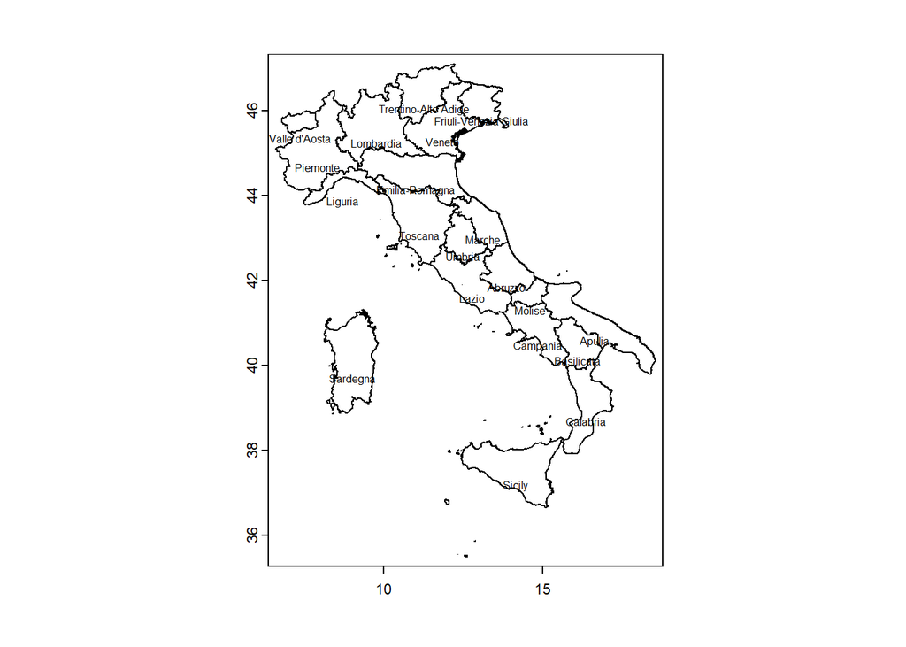

```r
plot(ita)

text(ita, label=ita$NAME_1, cex=0.5, pos=1)
```

## Elevation

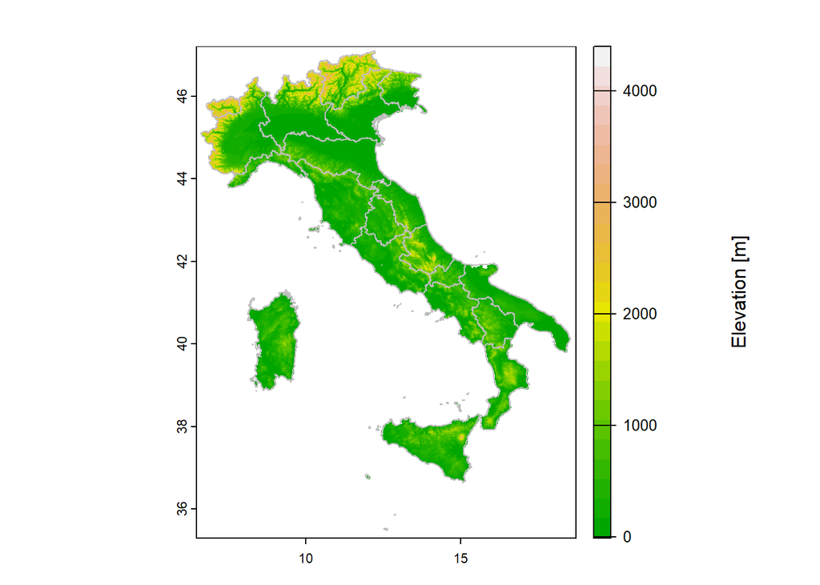

```r
##### ELEVATION DATA #####

ita_elev <- elevation_30s(country="ITA", mask=TRUE, path=getwd())

plot(ita_elev, col=terrain.colors(25))

lines(ita, lwd=1, col="gray")

mtext("Elevation [m]", side = 4, line = 0, at = mean(range(values(ita_elev))))
```

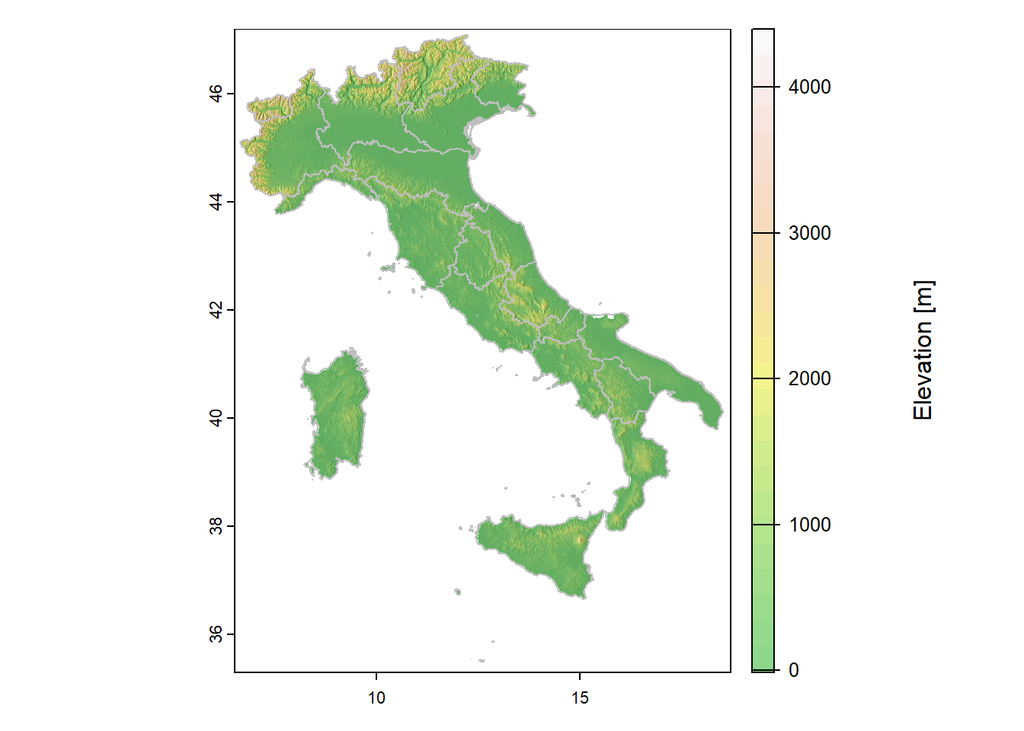

```r
# calculate aspect, slope for better visualization

slope <- terrain(ita_elev, "slope", unit="radians")

aspect <- terrain(ita_elev, "aspect", unit="radians")

hill <- shade(slope, aspect, 45, 270)

plot(hill, col=grey(0:100/100), legend=FALSE, mar=c(2,2,1,4))

plot(ita_elev, col=terrain.colors(25, alpha=0.45), add=TRUE, main="Topography")

lines(ita, lwd=1, col="gray")

mtext("Elevation [m]", side = 4, line = 0, at = mean(range(values(ita_elev))))
```

## Temperature

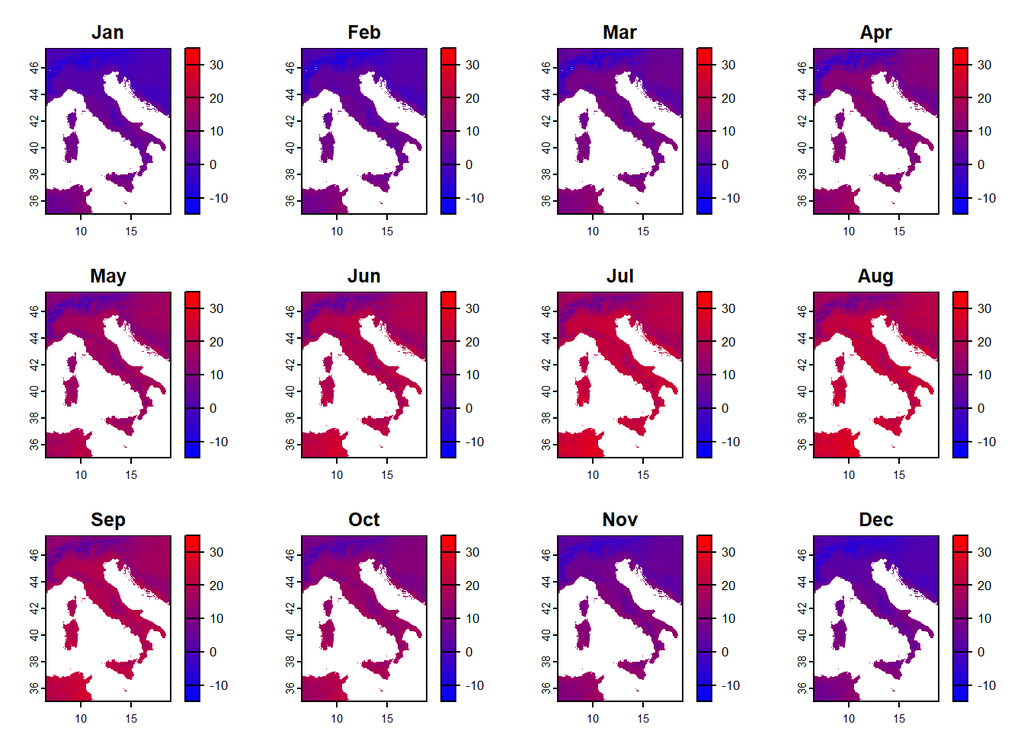

```r
##### TEMPERATURE DATA (WORLDCLIM) #####

ita_temp <- worldclim_country("ITA", var="tavg", path=tempdir())

colormap <- colorRampPalette(c("blue", "red"))(100)

plot(ita_temp,

     main=c("Jan", "Feb", "Mar", "Apr", "May", "Jun", "Jul", "Aug", "Sep", "Oct", "Nov", "Dec"),

     col=colormap,

     range=c(-15, 35)) # for equal colormaps
```

# 2 Ecochange

Measuring landscape changes in space and time: [documentation](https://cran.r-project.org/web/packages/ecochange/index.html)

**Workflow:**

- Import a *RasterBrick* containing different biodiversity variables for the Northern Amazon basin
- Calculate changes in layers of tree-canopy cover (TC) in the ‘amazon’ brick with `echanges(eco = 'TC')`
- Compute ecosystem statistics using `EBVstats`
- Compute ecosystem areas using `gaugeIndicator`
- Download country polygons with `getGADM` as well as remote sensing data with `getrsp` and `getWRS`

```r
# install.packages("ecochange")
library(ecochange)
#-------------------------------------------------------------------------------

## RasterBrick of structural Essential Biodiversity Variables
## covering the extent of a location in the northern Amazon basin
## (Colombia) is imported:
path. <- system.file('amazon.grd', package = 'ecochange')
amazon <- brick(path.)

# print available variables
names(amazon)
```

```
[1] "treecover2000" "lossyear"      "TC_2000"       "TC_2005"
[5] "TC_2010"       "TC_2015"       "nigricollis"
```

## Ecosystem changes

```r
##### echanges: Ecosystem changes #####
?echanges
# Changes in layers of tree-canopy cover (TC) in the 'amazon' brick are computed:
def <- echanges(amazon, eco = 'TC', # eco: Regular expression matching names of a subset of layers representing the target ecosystem variables
                change = 'lossyear',
                eco_range = c(1, 80),
                get_unaffected = TRUE,
                binary_output = FALSE,
                mc.cores = 2)
```

```
'eco' has length > 1: matching alphanumerics in 'eco' with values in 'change'...
```

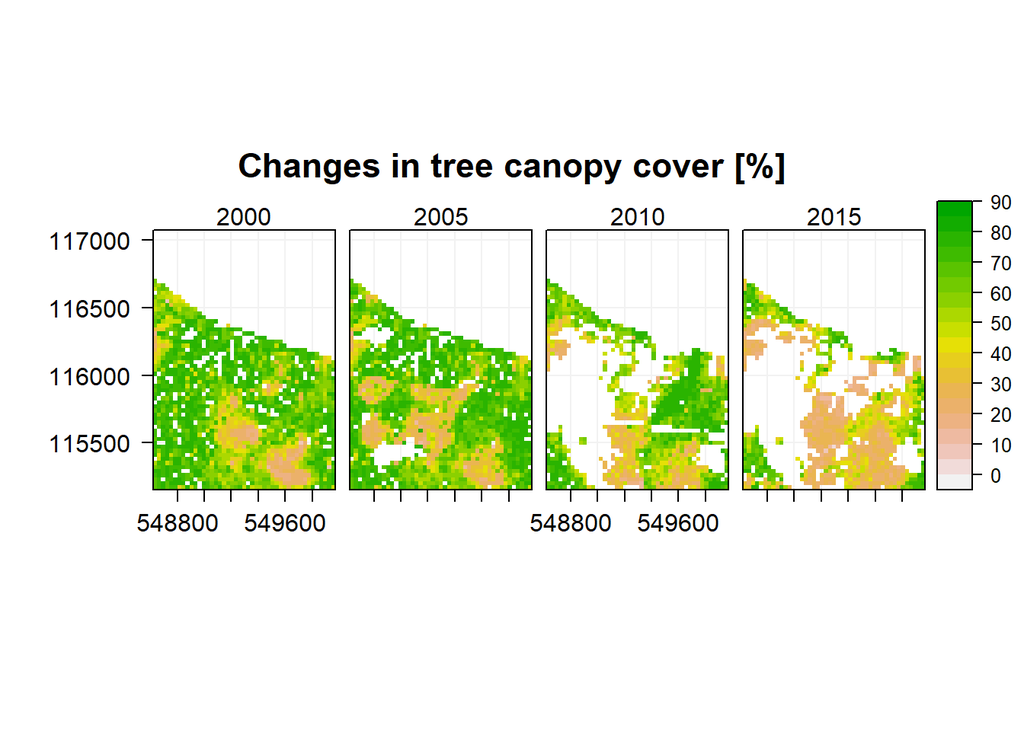

```r
# Method 'plot.echanges' allows comparing rasters using a common scale bar:
plot.echanges(def, main="Changes in tree canopy cover [%]",
              labels=c("2000", "2005", "2010", "2015"))
```

## Ecosystem statistics

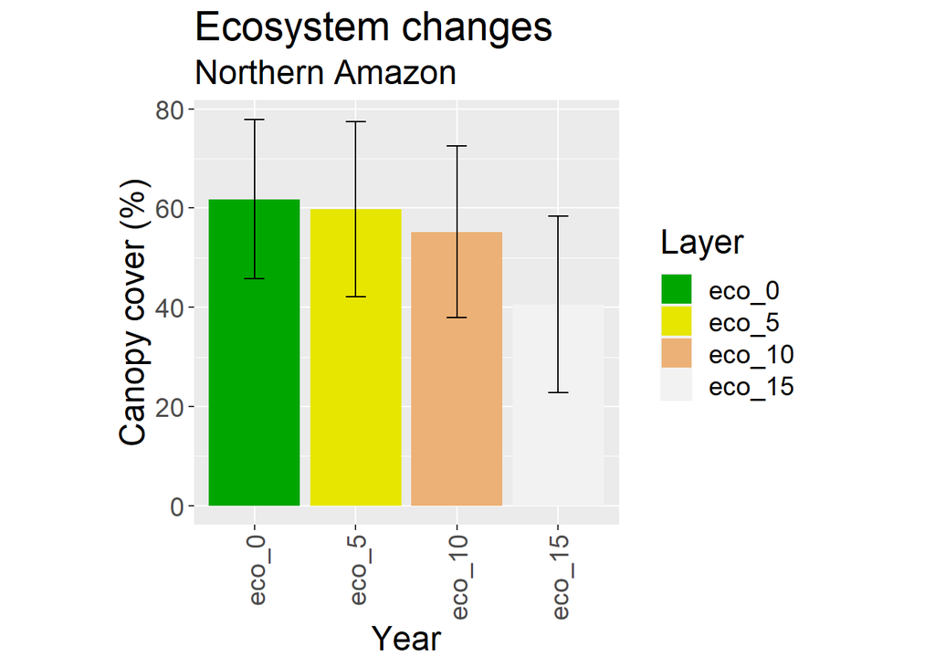

```r
##### EBVstats: compute ecosystem statistics #####
st_amazon <- EBVstats(def)
plot.EBVstats(st_amazon,
              cex = 1.5,
              xlab = 'Year',
              ylab = 'Canopy cover (%)',
              main = 'Ecosystem changes',
              sub = 'Northern Amazon',
              fill = 'Layer')
```

## Ecosystem areas (Gauge Indicator)

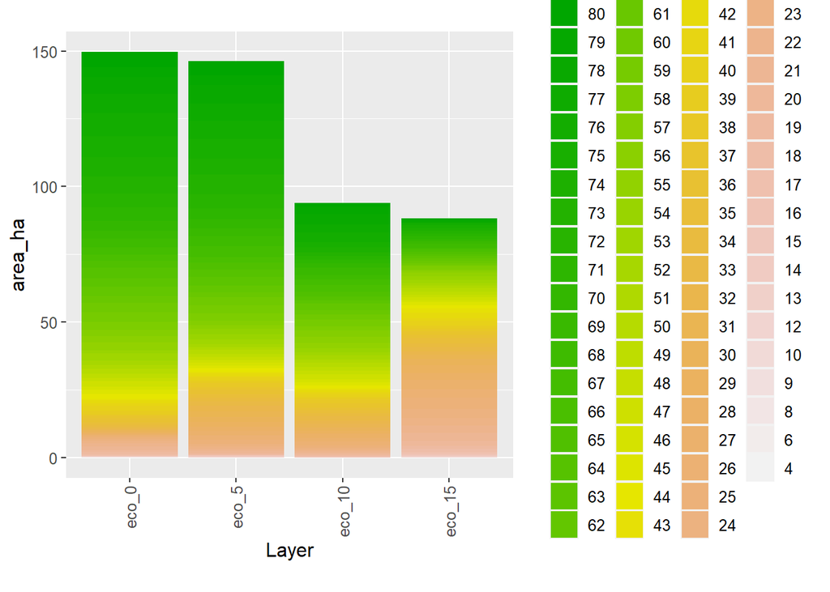

```r
# gaugeIndicator: compute ecosystem areas
am_areas <- gaugeIndicator(def,
                           mc.cores = 2)
plot.Indicator(am_areas)
```

## Download country and satellite data

Now let’s download a country polygon of Colombia as well as some Landsat data.

```r
# get country polygons with "getGADM"
# download respective remote sensing data.
# variables contain surface water, forest change, tree cover data
# for the entire list, see: listGP()
listGP()
```

```
# A tibble: 16 × 3
   layer         Algorithm                         author
   <chr>         <chr>                             <chr>
 1 occurrence    Global Surface Water              Pekel et.al., 2016
 2 change        Global Surface Water              Pekel et.al., 2016
 3 seasonality   Global Surface Water              Pekel et.al., 2016
 4 recurrence    Global Surface Water              Pekel et.al., 2016
 5 transition    Global Surface Water              Pekel et.al., 2016
 6 extent        Global Surface Water              Pekel et.al., 2016
 7 treecover2000 Global Forest Change              Hansen et.al., 2013
 8 lossyear      Global Forest Change              Hansen et.al., 2013
 9 gain          Global Forest Change              Hansen et.al., 2013
10 datamask      Global Forest Change              Hansen et.al., 2013
11 first         Global Forest Change              Hansen et.al., 2013
12 last          Global Forest Change              Hansen et.al., 2013
13 TC_2000       Global Continuous Tree Cover data Sexton et.al., 2013
14 TC_2005       Global Continuous Tree Cover data Sexton et.al., 2013
15 TC_2010       Global Continuous Tree Cover data Sexton et.al., 2013
16 TC_2015       Global Continuous Tree Cover data Sexton et.al., 2013
```

```r
# example Colombia
muni <- getGADM(unit.nm = NULL,
                level = 2, country = "COL",
                path = tempdir())
head(muni)
```

```
       Amazonas        Amazonas        Amazonas        Amazonas        Amazonas
   "El Encanto"   "La Chorrera"    "La Pedrera"   "La Victoria"       "Leticia"
       Amazonas
"Mirití-Paraná"
```

```r
## Polygon of the Colombian municipality of Cartagena del Chaira:
load(system.file('cchaira_roi.RData', package = 'ecochange'))
## A Global Surface Water layer ('seasonality') which covers the
## extent of the polygon is retrieved:
rsp_cchaira <- getrsp(cchaira_roi,
                      lyrs = 'seasonality', mc.cores = 2, path = tempdir())
```

```
Downloading files on C:/Users/Lukas/AppData/Local/Temp/RtmpYbsJ8H
```

```r
file.exists(rsp_cchaira)
```

```
[1] TRUE
```

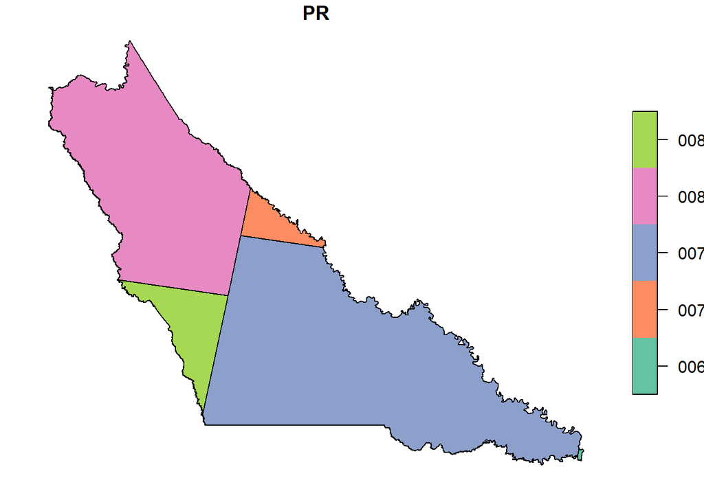

```r
## use getWRS to download Landsat data!
wrs_cchaira <- getWRS(cchaira_roi)
plot(wrs_cchaira)
```

# 3 FuzzySim

Calculating fuzzy similarity in species distributions. It can also produce the underlying fuzzy distribution data, e.g. through interpolating or modelling species presence-absence data: [documentation](https://cran.r-project.org/web/packages/fuzzySim/index.html)

**Important**

This package works with species occurrence data in presence-absence tables. If your data are point occurrences and raster maps, check out [this blog post](https://modtools.wordpress.com/2020/02/11/fuzzysim-updated-to-3-0-on-cran/) on how to convert them into tabular presence-absence data.

**Workflow:**

- Prepare data to be in presence-absence format (using sample data)
- Use rgdal `readOGR` function to download maps
- Convert binary to fuzzy occurrence data using
  1. Trend surface analysis (TSA)
  2. Inverse distance interpolation

## Mapping binary species occurence data

```r
# install.packages("fuzzySim")
library(fuzzySim)
library(rgdal)
library(vegan)

# Load rotifers sample dataset
data(rotifers)
help(rotifers)
head(rotifers)
```

```
    TDWG4                          species
1  DEN-OO Brachionus_plicatilis_plicatilis
11 DEN-OO  Keratella_cochlearis_cochlearis
15 DEN-OO      Keratella_quadrata_quadrata
16 DEN-OO             Asplanchna_priodonta
17 DEN-OO   Brachionus_angularis_angularis
19 DEN-OO                Filinia_longiseta
```

```r
### Preparing species occurence data ###

# species names too long for column names -> abbreviate with spCodes
rotifers$spcode <- spCodes(rotifers$species, sep.species = "_", nchar.gen = 1, nchar.sp = 5, nchar.ssp = 0, sep.spcode = "")
```

```
OK - no duplicated spcodes found.
```

```r
# important thing is that the names are unique -> see function output

# fuzzySim needs presence-absence data with species in cols!
rotifers_presabs <- splist2presabs(rotifers, sites.col = "TDWG4", sp.col = "spcode", keep.n = FALSE)
head(rotifers_presabs)
```

```
   TDWG4 Abrigh Afissa Apriod Bangul Bcalyc Bplica Bquadr Burceo Cgibba Edilat
1 ABT-OO      0      0      1      1      0      0      0      0      0      0
2 AFG-OO      1      0      1      1      1      1      1      1      1      0
3 AGE-BA      1      1      0      1      1      1      1      1      0      1
4 AGE-CD      0      0      0      1      0      1      1      0      0      1
5 AGE-CH      0      0      0      1      0      0      1      0      1      0
6 AGE-CN      0      0      0      0      1      1      1      0      0      1
  Flongi Kcochl Kquadr Ktropi Lbulla Lclost Lhamat Lluna Llunar Lovali Lpatel
1      1      1      1      0      0      0      0     1      1      1      0
2      0      1      1      1      1      1      1     1      0      1      1
3      1      1      1      1      1      1      1     1      1      1      0
4      1      1      0      0      1      1      0     1      1      1      0
5      1      0      0      1      1      1      1     0      1      1      0
6      1      0      1      0      0      0      0     1      0      1      0
  Lquadr Mventr Ppatul Pquadr Pvulga Specti Tpatin Tsimil Ttetra
1      0      0      1      0      1      1      0      0      1
2      1      0      1      1      1      0      1      1      0
3      1      1      1      1      1      0      1      0      1
4      1      1      0      0      1      0      0      1      0
5      1      1      1      1      1      0      0      1      1
6      0      1      1      1      1      0      0      1      0
```

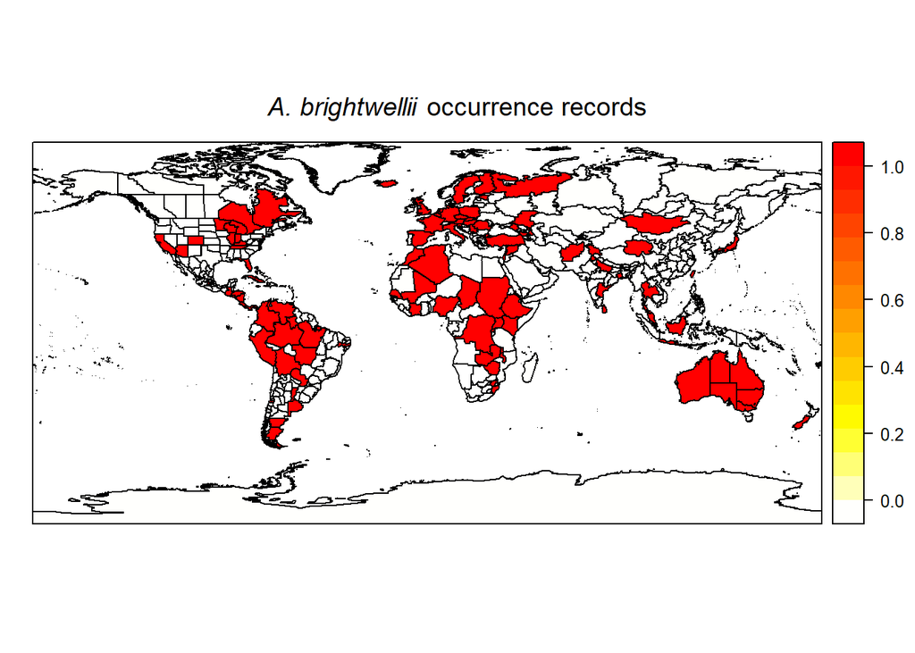

```r
### Mapping binary species occurence data ###

# use rgdal to download the TDWG level 4 maps
TDWG4shp <- readOGR(dsn = "https://raw.githubusercontent.com/tdwg/wgsrpd/master/geojson/level4.geojson")
# append species data to the respective region
TDWG4shp@data <- data.frame(TDWG4shp@data, rotifers_presabs[match(TDWG4shp@data$Level4_cod, rotifers_presabs$TDWG4), ])

# spplot from sp package
# choose species in param "zcol"
print(spplot(TDWG4shp, zcol = "Abrigh", col.regions = rev(heat.colors(256)), main = expression(paste(italic("A. brightwellii"), " occurrence records"))))
```

## Converting binary to fuzzy occurrence data

**Trend Surface Analysis (TSA) for multiple species**

Converts categorical presence-absence (1-0) data into continuous surfaces denoting the spatial trend in species’ occurrence patterns. Degree of polynomial needs to be selected!

**(Inverse) distance to the nearest presence**

Takes a matrix or data frame containing species presence (1) and absence (0) data and their spatial coordinates (optionally also a pre-calculated distance matrix between all localities), and calculates the (inverse) distance from each locality to the nearest presence locality for each species.

```r
### Converting binary to fuzzy occurrence data ###

#load data that contain also coordinates
data(rotif.env)
rotif_env <- rotif.env # convert for naming conventions
head(rotif_env)
```

```
   TDWG4   LEVEL_NAME            REGION_NAME        CONTINENT      Area
1 ABT-OO      Alberta         Western_Canada NORTHERN_AMERICA 663485.40
2 AFG-OO  Afghanistan           Western_Asia   ASIA-TEMPERATE 641921.77
3 AGE-BA Buenos_Aires Southern_South_America SOUTHERN_AMERICA 306187.95
4 AGE-CH        Chaco Southern_South_America SOUTHERN_AMERICA  99203.11
5 AGE-CN   Corrientes Southern_South_America SOUTHERN_AMERICA  88614.06
6 AGE-ER   Entre_Rios Southern_South_America SOUTHERN_AMERICA  78071.93
  Altitude AltitudeRange HabitatDiversity HumanPopulation  Latitude  Longitude
1   769.07          3346               12         3461492  54.95520 -114.45960
2  1797.41          6347               13        32755566  33.78802   65.98809
3    92.66          1092               12        15548773 -36.64692  -60.54985
4   115.57           230                7         1090382 -26.38870  -60.76430
5    67.60           195                9         1029757 -28.75806  -57.78881
6    44.22           125                9         1296896 -32.03426  -59.20174
  Precipitation PrecipitationSeasonality TemperatureAnnualRange Temperature
```

[output cut: 34 more lines]

```r
# to convert presence_absence occurence data to fuzzy data:
#     1) trend surface analysis (TSA)
      help(multTSA)
#     2) inverse distance interpolation
      help(distPres)

## 1)
# 3rd-degree polynomial with stepwise selection of terms:
rotifers_tsa <- multTSA(rotif_env, sp.cols = 18:47, coord.cols = c("Longitude", "Latitude"), id.col = 1, degree = 3, step = TRUE)
# now we have spatial trends in occurence for each species
head(rotifers_tsa)
```

```
   TDWG4 Abrigh_TS Afissa_TS  Apriod_TS Bangul_TS Bcalyc_TS Bplica_TS Bquadr_TS
1 ABT-OO 0.1798791 0.1072166 0.56679570 0.1749335 0.2038724 0.1290277 0.1699564
2 AFG-OO 0.4336780 0.4672791 0.41020511 0.6047653 0.6623104 0.4086573 0.5600267
3 AGE-BA 0.2415516 0.1213213 0.06354302 0.1983921 0.5761701 0.2155371 0.4680020
4 AGE-CH 0.3015052 0.1862872 0.06868535 0.2698491 0.5684838 0.2741569 0.4596102
5 AGE-CN 0.2838745 0.1681223 0.07063465 0.2515481 0.5786859 0.2594142 0.4673258
6 AGE-ER 0.2666956 0.1479148 0.06690217 0.2291874 0.5768053 0.2415501 0.4669809
  Burceo_TS Cgibba_TS Edilat_TS Flongi_TS Kcochl_TS Kquadr_TS  Ktropi_TS
1 0.1574877 0.4140185 0.4440554 0.4722511 0.8551909 0.5672359 0.01957571
2 0.4654481 0.2779111 0.5078315 0.5350268 0.5613394 0.4210410 0.46405849
3 0.1564815 0.1053790 0.6822418 0.5986828 0.6717552 0.2279913 0.47980394
4 0.1743961 0.2231089 0.5705167 0.5354029 0.5418227 0.1312679 0.41957365
5 0.1700648 0.1952903 0.5944190 0.5475202 0.5737098 0.1432048 0.45544798
6 0.1641862 0.1573235 0.6295697 0.5676605 0.6120463 0.1708383 0.46340796
  Lbulla_TS Lclost_TS Lhamat_TS  Lluna_TS Llunar_TS Lovali_TS Lpatel_TS
```

[output cut: 20 more lines]

```r
# check if value range is (0, 1)
range(rotifers_tsa[ , -1])
```

```
[1] 9.408071e-05 9.996004e-01
```

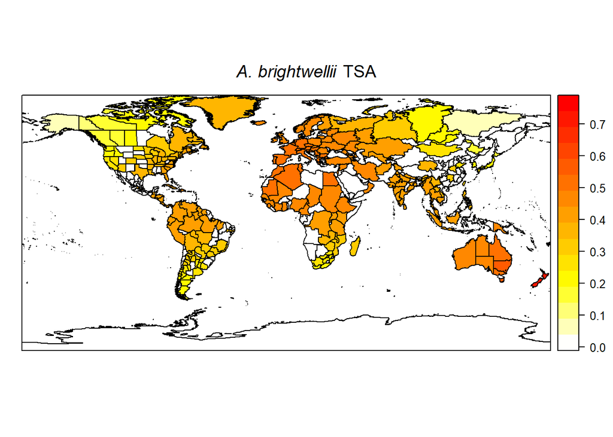

```r
# append results to the map table and plot
TDWG4shp@data <- data.frame(TDWG4shp@data, rotifers_tsa[match(TDWG4shp@data$Level4_cod, rotifers_tsa$TDWG4), ])
print(spplot(TDWG4shp, zcol = "Abrigh_TS", col.regions = rev(heat.colors(256)), main = expression(paste(italic("A. brightwellii"), " TSA"))))
```

```r
# consider trying different polynimoial degrees or stepwise selection!!

## 2)
rotifers_invdist <- distPres(rotif_env, sp.cols = 18:47, coord.cols = c("Longitude", "Latitude"), id.col = 1, p = 1, inv = TRUE, suffix = "_D")
# quick check of results
head(rotifers_invdist)
```

```
   TDWG4  Abrigh_D  Afissa_D  Apriod_D  Bangul_D  Bcalyc_D  Bplica_D Bquadr_D
1 ABT-OO 0.8199193 0.8178644 1.0000000 1.0000000 0.9049867 0.9152305 0.844641
2 AFG-OO 1.0000000 0.9028041 1.0000000 1.0000000 1.0000000 1.0000000 1.000000
3 AGE-BA 1.0000000 1.0000000 0.8133087 1.0000000 1.0000000 1.0000000 1.000000
4 AGE-CH 0.9610394 0.9610394 0.7779989 1.0000000 0.9719006 0.9719006 1.000000
5 AGE-CN 0.9637866 0.9637866 0.7522927 0.9637866 1.0000000 1.0000000 1.000000
6 AGE-ER 0.9782206 0.9782206 0.7661572 0.9782206 1.0000000 0.9782206 1.000000
   Burceo_D  Cgibba_D  Edilat_D  Flongi_D  Kcochl_D  Kquadr_D  Ktropi_D
1 0.8446410 0.9004828 0.9049867 1.0000000 1.0000000 1.0000000 0.8178644
2 1.0000000 1.0000000 0.9028041 0.9028041 1.0000000 1.0000000 1.0000000
3 1.0000000 0.9409741 1.0000000 1.0000000 1.0000000 1.0000000 1.0000000
4 0.9610394 1.0000000 0.9719006 1.0000000 0.9719006 0.9625672 1.0000000
5 0.9637866 0.9637866 1.0000000 1.0000000 0.9648868 1.0000000 0.9648868
6 0.9782206 0.9782206 1.0000000 1.0000000 1.0000000 0.9648868 1.0000000
   Lbulla_D  Lclost_D  Lhamat_D   Lluna_D  Llunar_D  Lovali_D  Lpatel_D
```

[output cut: 20 more lines]

```r
range(rotifers_invdist[ , -1])
```

```
[1] 0 1
```

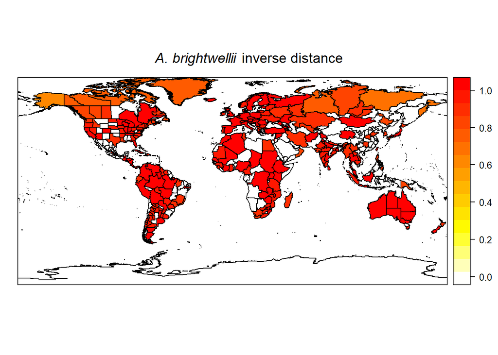

```r
# Note that inverse distance to presence is calculated only for absence localities;
# distPres maintains the value 1 for presences
TDWG4shp@data <- data.frame(TDWG4shp@data, rotifers_invdist[match(TDWG4shp@data$Level4_cod, rotifers_invdist$TDWG4), ])
print(spplot(TDWG4shp, zcol = "Abrigh_D", col.regions = rev(heat.colors(256)), main = expression(paste(italic("A. brightwellii"), " inverse distance"))))
```

```r
# Note that distance is also not always a good fuzzy representation of a species’
# occurrence area, as geographical and environmental barriers may cause sharp
# local variations in species’ occurrence patterns.
```

## Distribution models with environmental data

```r
### Distribution models with environmental data ###

# Another way of obtaining fuzzy versions of species occurrence is to build
# distribution models based on the relationship between species presence/absence
# and a set of geographical, environmental and/or human variables.
help(multGLM) # for more information

rotifers_fav <- multGLM(data = rotif_env, sp.cols = 18:47, var.cols = 5:17, id.col = 1)
```

```
=> Building model 1 of 30 (Abrigh)...

13 input predictor variable(s)

6 variable(s) excluded by 'step' function
Altitude, Latitude, Longitude, TemperatureAnnualRange, Temperature, UrbanArea

1 variable(s) excluded by 'modelTrim' function
 AltitudeRange

6 variable(s) INCLUDED IN THE FINAL MODEL
 HabitatDiversity, TemperatureSeasonality, Area, Precipitation, PrecipitationSeasonality, HumanPopulation



=> Building model 2 of 30 (Afissa)...

13 input predictor variable(s)

3 variable(s) excluded by 'step' function
Area, AltitudeRange, Precipitation

4 variable(s) excluded by 'modelTrim' function
 HumanPopulation, HabitatDiversity, Altitude, Temperature

6 variable(s) INCLUDED IN THE FINAL MODEL
 UrbanArea, TemperatureSeasonality, Longitude, Latitude, TemperatureAnnualRange, PrecipitationSeasonality



=> Building model 3 of 30 (Apriod)...

13 input predictor variable(s)

8 variable(s) excluded by 'step' function
Altitude, AltitudeRange, HumanPopulation, Precipitation, TemperatureAnnualRange, Temperature, TemperatureSeasonality, UrbanArea

1 variable(s) excluded by 'modelTrim' function
 HabitatDiversity

```

[output cut: 392 more lines]

```



=> Building model 30 of 30 (Ttetra)...

13 input predictor variable(s)

6 variable(s) excluded by 'step' function
AltitudeRange, Latitude, Longitude, Precipitation, PrecipitationSeasonality, UrbanArea

0 variable(s) excluded by 'modelTrim' function


7 variable(s) INCLUDED IN THE FINAL MODEL
 Area, HumanPopulation, HabitatDiversity, Altitude, Temperature, TemperatureSeasonality, TemperatureAnnualRange
```

```r
head(rotifers_fav$predictions)
```

```
   TDWG4  Abrigh_P  Afissa_P   Apriod_P  Bangul_P  Bcalyc_P  Bplica_P  Bquadr_P
1 ABT-OO 0.2882603 0.1138959 0.50361345 0.2468886 0.4472060 0.1951515 0.3596388
2 AFG-OO 0.4906287 0.3722796 0.46087753 0.6977093 0.6956644 0.3701844 0.5750892
3 AGE-BA 0.6119061 0.1219451 0.08208813 0.4312721 0.7377861 0.3220030 0.4657336
4 AGE-CH 0.1376871 0.1565695 0.05817764 0.2925746 0.4468215 0.2508469 0.2904811
5 AGE-CN 0.2667640 0.1489743 0.08835735 0.3142329 0.5320916 0.2031516 0.3667903
6 AGE-ER 0.2662901 0.1337515 0.07444270 0.3060692 0.5446412 0.2238783 0.3269149
    Burceo_P  Cgibba_P  Edilat_P  Flongi_P  Kcochl_P   Kquadr_P  Ktropi_P
1 0.20728200 0.3421701 0.5525130 0.7325116 0.8446163 0.70544804 0.0267022
2 0.55870506 0.1794636 0.6698224 0.7912660 0.6847209 0.59711189 0.6494431
3 0.49949786 0.2152587 0.6099271 0.6635060 0.8898363 0.63541290 0.6639190
4 0.08950173 0.1686463 0.3128215 0.2250847 0.3071935 0.06945265 0.3359397
5 0.18076778 0.1429014 0.3737592 0.3644676 0.5555601 0.18225500 0.3678857
6 0.18778977 0.1621041 0.3898079 0.3622259 0.6041055 0.22765216 0.3891151
   Lbulla_P  Lclost_P  Lhamat_P   Lluna_P  Llunar_P  Lovali_P  Lpatel_P
```

[output cut: 48 more lines]

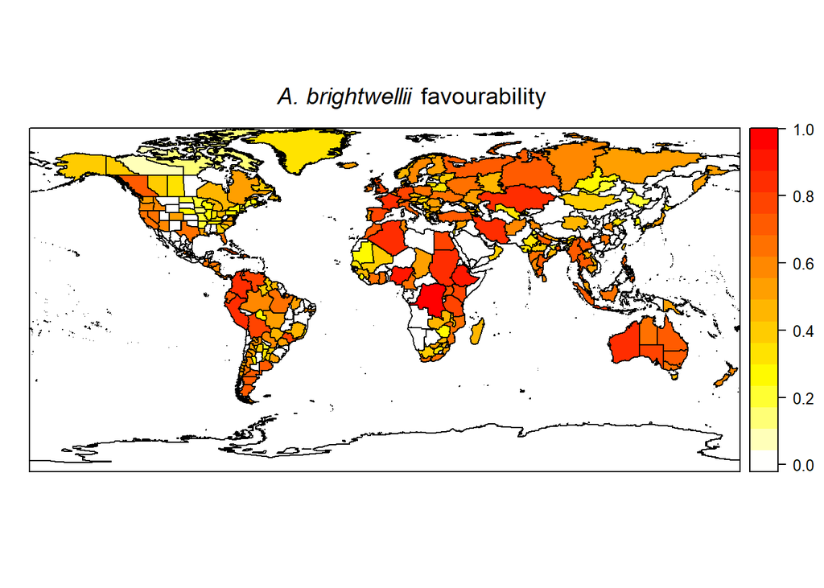

```r
# append predictions to the map data and plot
TDWG4shp@data <- data.frame(TDWG4shp@data, rotifers_fav$predictions[match(TDWG4shp@data$Level4_cod, rotifers_fav$predictions$TDWG4), ])
print(spplot(TDWG4shp, zcol = "Abrigh_F", col.regions = rev(heat.colors(256)), main = expression(paste(italic("A. brightwellii"), " favourability"))))
```

```r
### Calculating (fuzzy) similarity among species occurrence patterns ###

# now use these favourability model predictions as fuzzy occurrence values
# get a matrix of pair-wise fuzzy similarity among these fuzzy species’ distributions,
# by comparing these columns with e.g. the fuzzy Jaccard similarity index
fuz_sim_mat <- simMat(rotifers_fav$predictions[ , 32:61], method = "Jaccard")
```

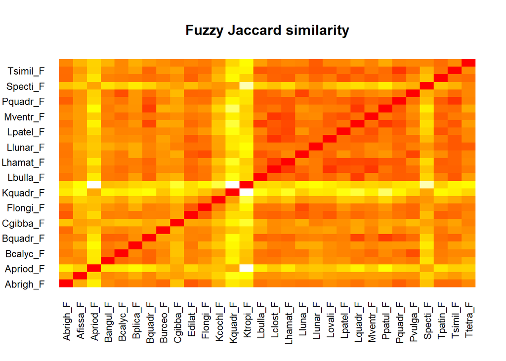

```r
# similarity matrix
image(x = 1:ncol(fuz_sim_mat), y = 1:nrow(fuz_sim_mat), z = fuz_sim_mat, col = rev(heat.colors(256)), xlab = "", ylab = "", axes = FALSE, main = "Fuzzy Jaccard similarity")
axis(side = 1, at = 1:ncol(fuz_sim_mat), tick = FALSE, labels = colnames(fuz_sim_mat), las = 2, cex.axis = 0.8)
axis(side = 2, at = 1:nrow(fuz_sim_mat), tick = FALSE, labels = rownames(fuz_sim_mat), las = 2, cex.axis = 0.8)
```

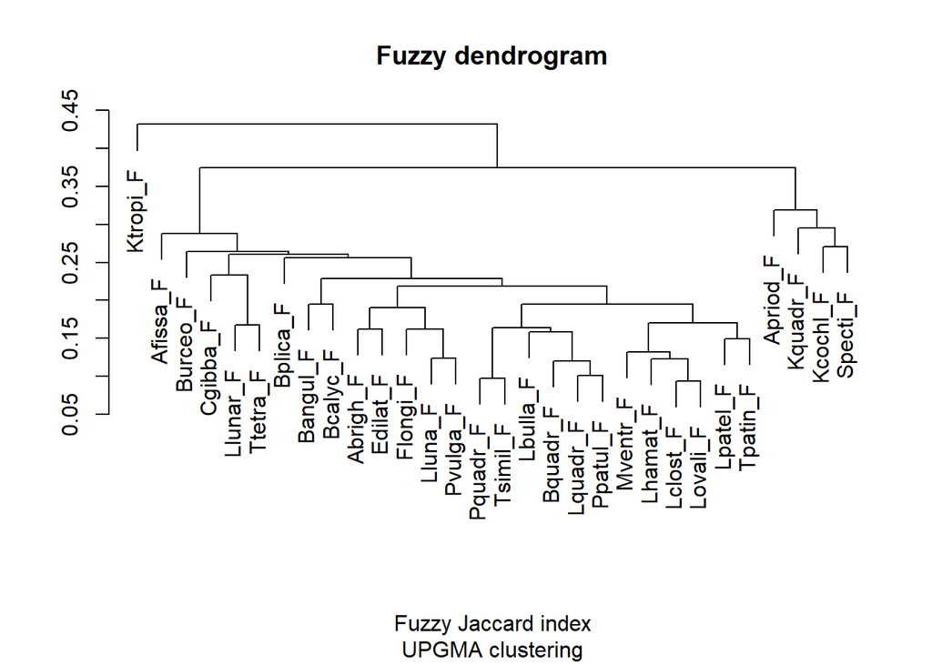

```r
# build cluster dendrogram from the similarity matrix using "hclust"
fuz_dendro <- hclust(as.dist(1 - fuz_sim_mat), method = "average")
plot(fuz_dendro, main = "Fuzzy dendrogram", xlab = "", ylab = "", sub = "Fuzzy Jaccard index\nUPGMA clustering")
```

```r
# build a similarity matrix from the original binary presence-absence data
# to compare with the fuzzy similarity results
bin_sim_mat <- simMat(rotif_env[ , 18:47], method = "Jaccard")
```

```r
mantel(bin_sim_mat, fuz_sim_mat, method = "spearman")
```

```
Mantel statistic based on Spearman's rank correlation rho

Call:
mantel(xdis = bin_sim_mat, ydis = fuz_sim_mat, method = "spearman")

Mantel statistic r: 0.6778
      Significance: 0.001

Upper quantiles of permutations (null model):
  90%   95% 97.5%   99%
0.165 0.225 0.285 0.315
Permutation: free
Number of permutations: 999
```